# Challenge 1 - alternative machine learning approach

CODE LANGUAGE: R

I have run other unsupervised and machine learning models to compare with the panel data model submitted before. I have run trees, random forests and boosting models, with hierarchical and k-means clustering that nevertheless are outperformed by the panel data model. Thus, I have not changed the MAPE and predicted output in Github

```r
require(ISLR)
require(tree)
require(randomForest)
require(gbm)
```

Reads the training dataset, creates dataframe and creates cross variable (Daylight x Temperature) that enhances prediction as we saw in the panel data model

```r
training <- read.csv("training_dataset_500.csv")
df <- data.frame(training)
df$cross <- df$Daylight * df$Temperature
```

As we saw in the panel data model, there are house-wise idiosyncratic effects. We plot Energy production means to see if we can can cluster the idiosyncratic effects There are 6 clusters!

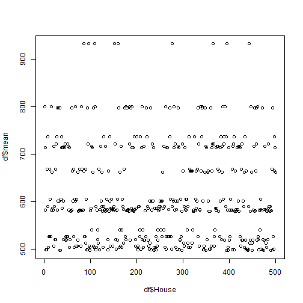

```r
df$mean <- ave(df$EnergyProduction, df$House)
plot(df$House, df$mean)
```

```r
km.out = kmeans(df$mean, 6, nstart = 15)
km.out[2]
```

```
## $centers
##    [,1]
## 1 512.6
## 2 665.1
## 3 798.6
## 4 933.1
## 5 722.0
## 6 588.2
```

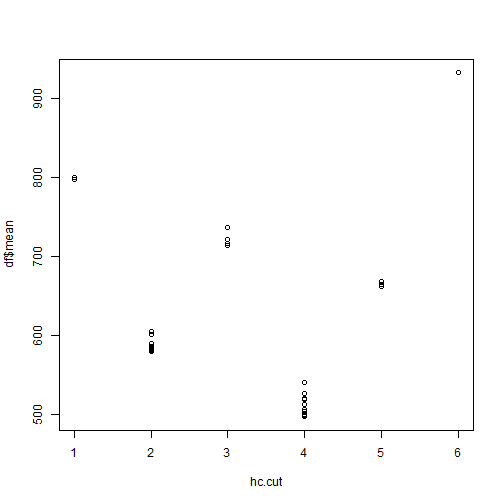

```r
hc.complete = hclust(dist(df$mean), method = "complete")
hc.cut = cutree(hc.complete, 6)
plot(hc.cut, df$mean)
```

```r
df$cluster <- hc.cut
```

We subset the training data into the six clusters

```r
for (i in 1:6) {
    assign(paste("sub", i, sep = ""), subset(df, df$cluster == i))
}
```

TREES

We run a tree model for each of the six clusters. Pooling the six clusters would have missed the house-wise idiosyncratic effects, so we run it by clusters to get the variation

```r
tree.energy1 <- tree(EnergyProduction ~ Daylight + Temperature + cross, data = sub1)
tree.energy2 <- tree(EnergyProduction ~ Daylight + Temperature + cross, data = sub2)
tree.energy3 <- tree(EnergyProduction ~ Daylight + Temperature + cross, data = sub3)
tree.energy4 <- tree(EnergyProduction ~ Daylight + Temperature + cross, data = sub4)
tree.energy5 <- tree(EnergyProduction ~ Daylight + Temperature + cross, data = sub5)
tree.energy6 <- tree(EnergyProduction ~ Daylight + Temperature + cross, data = sub6)
summary(tree.energy1)
```

```
##
## Regression tree:
## tree(formula = EnergyProduction ~ Daylight + Temperature + cross,
##     data = sub1)
## Variables actually used in tree construction:
## [1] "Daylight"    "Temperature"
## Number of terminal nodes:  11
## Residual mean deviance:  752 = 666000 / 886
## Distribution of residuals:
##    Min. 1st Qu.  Median    Mean 3rd Qu.    Max.
##  -42.20  -23.40    1.47    0.00   12.60   86.80
```

These are the trees

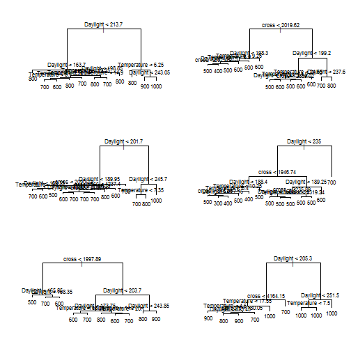

```r
par(mfrow = c(3, 2))
plot(tree.energy1)
text(tree.energy1, pretty = 0)
plot(tree.energy2)
text(tree.energy2, pretty = 0)
plot(tree.energy3)
text(tree.energy3, pretty = 0)
plot(tree.energy4)
text(tree.energy4, pretty = 0)
plot(tree.energy5)
text(tree.energy5, pretty = 0)
plot(tree.energy6)
text(tree.energy6, pretty = 0)
```

We read the test data and estimate MAPE stats

```r
test <- read.csv("test_dataset_500.csv")
df.test <- data.frame(test)
df.test$cross <- df.test$Daylight * df.test$Temperature

t1 <- df.test[which(df.test$House %in% unique(sub1$House)), ]
t2 <- df.test[which(df.test$House %in% unique(sub2$House)), ]
t3 <- df.test[which(df.test$House %in% unique(sub3$House)), ]
t4 <- df.test[which(df.test$House %in% unique(sub4$House)), ]
t5 <- df.test[which(df.test$House %in% unique(sub5$House)), ]
t6 <- df.test[which(df.test$House %in% unique(sub6$House)), ]

t1$tree <- predict(tree.energy1, t1)
t2$tree <- predict(tree.energy2, t2)
t3$tree <- predict(tree.energy3, t3)
t4$tree <- predict(tree.energy4, t4)
t5$tree <- predict(tree.energy5, t5)
t6$tree <- predict(tree.energy6, t6)

testing <- rbind(t1, t2, t3, t4, t5, t6)
testing <- testing[order(testing$House), ]

testing$errorTree <- abs(testing$EnergyProduction - testing$tree)/testing$EnergyProduction
```

Trees MAPE (outperformed by the panel-data model):

```r
ave(testing$errorTree)[1]
```

```
## [1] 0.07409
```

RANDOM FORESTS

We run random forest models for each of the six clusters. Again, pooling the six clusters would have missed the house-wise idiosyncratic effects

```r
rf.energy1 <- randomForest(EnergyProduction ~ Daylight + Temperature + cross,
    data = sub1)
rf.energy2 <- randomForest(EnergyProduction ~ Daylight + Temperature + cross,
    data = sub2)
rf.energy3 <- randomForest(EnergyProduction ~ Daylight + Temperature + cross,
    data = sub3)
rf.energy4 <- randomForest(EnergyProduction ~ Daylight + Temperature + cross,
    data = sub4)
rf.energy5 <- randomForest(EnergyProduction ~ Daylight + Temperature + cross,
    data = sub5)
rf.energy6 <- randomForest(EnergyProduction ~ Daylight + Temperature + cross,
    data = sub6)
```

We do observe some variation accross clusters in terms of prediction and suitable variables

```r
rf.energy1
```

```
##
## Call:
##  randomForest(formula = EnergyProduction ~ Daylight + Temperature +      cross, data = sub1)
##                Type of random forest: regression
##                      Number of trees: 500
## No. of variables tried at each split: 1
##
##           Mean of squared residuals: 0.09591
##                     % Var explained: 100
```

```r
rf.energy2
```

```
##
## Call:
##  randomForest(formula = EnergyProduction ~ Daylight + Temperature +      cross, data = sub2)
##                Type of random forest: regression
##                      Number of trees: 500
## No. of variables tried at each split: 1
##
##           Mean of squared residuals: 3.884
##                     % Var explained: 99.96
```

```r
rf.energy3
```

```
##
## Call:
##  randomForest(formula = EnergyProduction ~ Daylight + Temperature +      cross, data = sub3)
##                Type of random forest: regression
##                      Number of trees: 500
## No. of variables tried at each split: 1
##
##           Mean of squared residuals: 6.434
##                     % Var explained: 99.95
```

```r
rf.energy4
```

```
##
## Call:
##  randomForest(formula = EnergyProduction ~ Daylight + Temperature +      cross, data = sub4)
##                Type of random forest: regression
##                      Number of trees: 500
## No. of variables tried at each split: 1
##
##           Mean of squared residuals: 10.45
##                     % Var explained: 99.85
```

```r
rf.energy5
```

```
##
## Call:
##  randomForest(formula = EnergyProduction ~ Daylight + Temperature +      cross, data = sub5)
##                Type of random forest: regression
##                      Number of trees: 500
## No. of variables tried at each split: 1
##
##           Mean of squared residuals: 0.9175
##                     % Var explained: 99.99
```

```r
rf.energy6
```

```
##
## Call:
##  randomForest(formula = EnergyProduction ~ Daylight + Temperature +      cross, data = sub6)
##                Type of random forest: regression
##                      Number of trees: 500
## No. of variables tried at each split: 1
##
##           Mean of squared residuals: 0.002238
##                     % Var explained: 100
```

We predict the output with the test data and estimate MAPE stats

```r
t1$RF <- predict(rf.energy1, t1)
t2$RF <- predict(rf.energy2, t2)
t3$RF <- predict(rf.energy3, t3)
t4$RF <- predict(rf.energy4, t4)
t5$RF <- predict(rf.energy5, t5)
t6$RF <- predict(rf.energy6, t6)

testingRF <- rbind(t1, t2, t3, t4, t5, t6)
testingRF <- testingRF[order(testingRF$House), ]

testingRF$errorRF <- abs(testingRF$EnergyProduction - testingRF$RF)/testingRF$EnergyProduction
```

Random forests MAPE (again outperformed by the panel-data model):

```r
ave(testingRF$errorRF)[1]
```

```
## [1] 0.06686
```

BOOSTING

We run boosting models for each of the six clusters. Again, pooling the six clusters would have missed the house-wise idiosyncratic effects

```r
boost.energy1 <- gbm(EnergyProduction ~ Daylight + Temperature + cross, data = sub1,
    distribution = "gaussian", n.trees = 10000, shrinkage = 0.01, interaction.depth = 6)
boost.energy2 <- gbm(EnergyProduction ~ Daylight + Temperature + cross, data = sub2,
    distribution = "gaussian", n.trees = 10000, shrinkage = 0.01, interaction.depth = 6)
boost.energy3 <- gbm(EnergyProduction ~ Daylight + Temperature + cross, data = sub3,
    distribution = "gaussian", n.trees = 10000, shrinkage = 0.01, interaction.depth = 6)
boost.energy4 <- gbm(EnergyProduction ~ Daylight + Temperature + cross, data = sub4,
    distribution = "gaussian", n.trees = 10000, shrinkage = 0.01, interaction.depth = 6)
boost.energy5 <- gbm(EnergyProduction ~ Daylight + Temperature + cross, data = sub5,
    distribution = "gaussian", n.trees = 10000, shrinkage = 0.01, interaction.depth = 6)
boost.energy6 <- gbm(EnergyProduction ~ Daylight + Temperature + cross, data = sub6,
    distribution = "gaussian", n.trees = 10000, shrinkage = 0.01, interaction.depth = 6)
```

We can observe the variation accross clusters in terms of the relevance of each variable for each cluster

```r
par(mfrow = c(3, 2))
summary(boost.energy1)
```

```
##                     var rel.inf
## Daylight       Daylight  77.526
## Temperature Temperature  18.843
## cross             cross   3.631
```

```r
summary(boost.energy2)
```

```
##                     var rel.inf
## Daylight       Daylight   44.52
## cross             cross   42.51
## Temperature Temperature   12.97
```

```r
summary(boost.energy3)
```

```
##                     var rel.inf
## Daylight       Daylight   70.22
## cross             cross   17.20
## Temperature Temperature   12.57
```

```r
summary(boost.energy4)
```

```
##                     var rel.inf
## Daylight       Daylight   62.81
## cross             cross   24.90
## Temperature Temperature   12.29
```

```r
summary(boost.energy5)
```

```
##                     var rel.inf
## cross             cross   52.71
## Daylight       Daylight   37.22
## Temperature Temperature   10.07
```

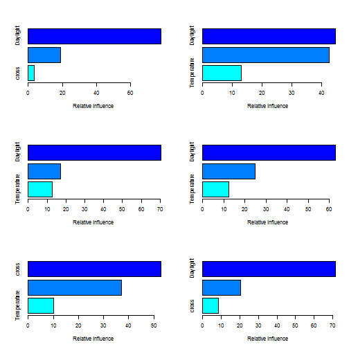

```
##                     var rel.inf
## Daylight       Daylight  71.378
## Temperature Temperature  20.264
## cross             cross   8.359
```

```r
summary(boost.energy6)
```

We can also observe the variation accross clusters in terms of changing marginal effects by variable

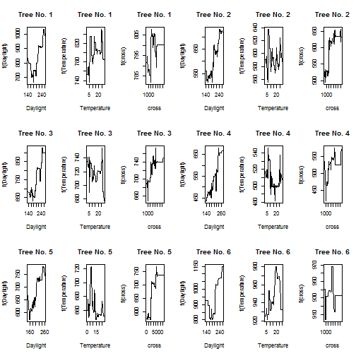

```r
par(mfrow = c(3, 6))
plot(boost.energy1, i = "Daylight", main = "Tree No. 1")
plot(boost.energy1, i = "Temperature", main = "Tree No. 1")
plot(boost.energy1, i = "cross", main = "Tree No. 1")
plot(boost.energy2, i = "Daylight", main = "Tree No. 2")
plot(boost.energy2, i = "Temperature", main = "Tree No. 2")
plot(boost.energy2, i = "cross", main = "Tree No. 2")
plot(boost.energy3, i = "Daylight", main = "Tree No. 3")
plot(boost.energy3, i = "Temperature", main = "Tree No. 3")
plot(boost.energy3, i = "cross", main = "Tree No. 3")
plot(boost.energy4, i = "Daylight", main = "Tree No. 4")
plot(boost.energy4, i = "Temperature", main = "Tree No. 4")
plot(boost.energy4, i = "cross", main = "Tree No. 4")
plot(boost.energy5, i = "Daylight", main = "Tree No. 5")
plot(boost.energy5, i = "Temperature", main = "Tree No. 5")
plot(boost.energy5, i = "cross", main = "Tree No. 5")
plot(boost.energy6, i = "Daylight", main = "Tree No. 6")
plot(boost.energy6, i = "Temperature", main = "Tree No. 6")
plot(boost.energy6, i = "cross", main = "Tree No. 6")
```

We predict the output and select the size of the tree that avoids overfitting. We do that by finding the tree that minimizes the test MAPE, knowing that increasing the size of the tree reduces the training MAPE but may overfit.

```r
n.trees <- seq(from = 100, to = 10000, by = 100)

boost1 <- predict(boost.energy1, newdata = t1, n.trees = n.trees)
error1 <- abs(t1$EnergyProduction - boost1)/t1$EnergyProduction
v1 <- which.min(colMeans(error1))
t1$boost <- boost1[, v1]

boost2 <- predict(boost.energy2, newdata = t2, n.trees = n.trees)
error2 <- abs(t2$EnergyProduction - boost2)/t2$EnergyProduction
v2 <- which.min(colMeans(error2))
t2$boost <- boost2[, v2]

boost3 <- predict(boost.energy3, newdata = t3, n.trees = n.trees)
error3 <- abs(t3$EnergyProduction - boost3)/t3$EnergyProduction
v3 <- which.min(colMeans(error3))
t3$boost <- boost3[, v3]

boost4 <- predict(boost.energy4, newdata = t4, n.trees = n.trees)
error4 <- abs(t4$EnergyProduction - boost4)/t4$EnergyProduction
v4 <- which.min(colMeans(error4))
t4$boost <- boost4[, v4]

boost5 <- predict(boost.energy5, newdata = t5, n.trees = n.trees)
error5 <- abs(t5$EnergyProduction - boost5)/t5$EnergyProduction
v5 <- which.min(colMeans(error5))
t5$boost <- boost5[, v5]

boost6 <- predict(boost.energy6, newdata = t6, n.trees = n.trees)
error6 <- abs(t6$EnergyProduction - boost6)/t6$EnergyProduction
v6 <- which.min(colMeans(error6))
t6$boost <- boost6[, v6]
```

We can check how the test MAPE varies accross clusters

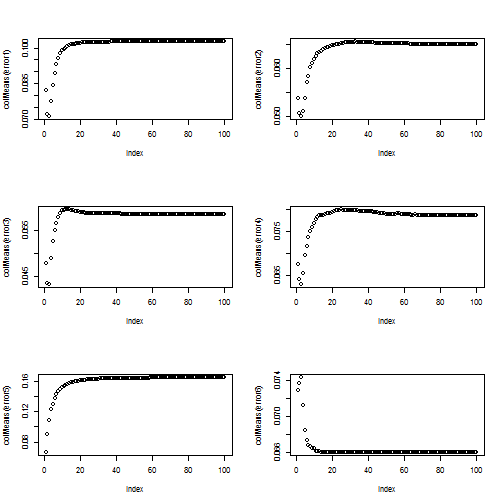

```r
par(mfrow = c(3, 2))
plot(colMeans(error1))
plot(colMeans(error2))
plot(colMeans(error3))
plot(colMeans(error4))
plot(colMeans(error5))
plot(colMeans(error6))
```

We find MAPE stats of the optimal tree

```r
testingboost <- rbind(t1, t2, t3, t4, t5, t6)
testingboost <- testingboost[order(testingboost$House), ]

testingboost$errorboost <- abs(testingboost$EnergyProduction - testingboost$boost)/testingboost$EnergyProduction
```

Boosting MAPE (again outperformed by the panel-data model):

```r
ave(testingboost$errorboost)[1]
```

```
## [1] 0.05668
```

My guess is that these methods do not account well for the house-wise idiosyncratic effects. They do capture the effect to some extent by clustering, but is not as precise as the panel data model.

Another method could have been running 500 clusters by house, but we only have 23 observations per house which is not statistically significant

Thanks for reading!